# Bayesian Examples

Dave Vanness

10/19/2021

## Introduction

The purpose of this R-markdown document is to demonstrate simple Bayesian linear model estimation in the context of treatment effects regression using simulated data. We estimate classical models using ordinary least squares and compare them with ANOVA. We then estimate the equivalent Bayesian models with JAGS (demonstrating the syntax of JAGS code) and compare them with the deviance information criterion (DIC). Finally, we use the package rstanarm to estimate the models using syntax similar to classical modeling. We finally use the package LOO to compare models using Pareto-Smoothed Importance Sampling Leave-One-Out posterior distributions (PSIS-LOO) and construct posterior model probabilities and weights.

## Preliminaries

First, we clear memory and load required packages:

```r
rm(list = ls())

library(tidyverse)
library(runjags)
library(rjags)
library(rstan)
library(rstanarm)
library(loo)
options(mc.cores = 4)
logit = function(x) {
  exp(x) / (1 + exp(x))
}
```

## Simulated dataset

Next, we generate a simulated RCT dataset with $N=500$. We have 3 slightly correlated covariates, $X_1$, $X_2$ and $X_3$, and a randomly-assigned treatment $TX$. The outcome $Y$ is a function of covariates and treatment and effect modifier $X_1$. The true effects of covariates and treatment are known:

Treatment is effective, increasing $Y$ by 0.5 units. Treatment effectiveness increases 0.25 per unit increase in $X_1$. Note, this heterogeneous treatment effect suggests that persons with $X_1 < -2$ are harmed by treatment.

```r
set.seed(446090)
N = 500
X = MASS::mvrnorm(n = N,
                  mu = c(0, 0, 0),
                  Sigma = matrix(
                    data = c(1, 0.3, -0.3,
                             0.3, 1, 0.2,
                             -0.3, 0.2, 1),
                    nrow = 3
                  ))
TX = rbinom(n = N, size = 1, prob = .5)
mu_Y = -0.3 * X[, 1] + 0.5 * X[, 2] - 0.5 * X[, 3] + 0.5 * TX + .25 * TX *
  X[, 1]
Y = rnorm(n = N, mean = mu_Y, sd = 1)
D = tibble(
  Y = Y,
  TX = TX,
  X1 = X[, 1],
  X2 = X[, 2],
  X3 = X[, 3]
)
```

## Ordinary Least Squares

First, we conduct treatment effects linear regression using 3 specifications:

1. A minimal model (with no treatment x covariate interactions)
2. A full model (treatment x covariate interactions for $X_1$, $X_2$, and $X_3$)
3. The true model (treatment x covariate interactions for $X_1$ only)

```r
lm.min = lm(Y ~ X1 + X2 + X3 + TX, data = D)
lm.full = lm(Y ~ X1 + X2 + X3 + TX + X1 * TX + X2 * TX + X3 * TX, data = D)
lm.true = lm(Y ~ X1 + X2 + X3 + TX + X1 * TX, data = D)

print(summary(lm.min))
```

```
##
## Call:
## lm(formula = Y ~ X1 + X2 + X3 + TX, data = D)
##
## Residuals:
##      Min       1Q   Median       3Q      Max
## -3.06862 -0.67609 -0.00567  0.57240  3.03158
##
## Coefficients:
##             Estimate Std. Error t value Pr(>|t|)
## (Intercept) -0.04891    0.06057  -0.807  0.41981
## X1          -0.14089    0.05029  -2.801  0.00529 **
## X2           0.56581    0.04877  11.601  < 2e-16 ***
## X3          -0.51903    0.05115 -10.147  < 2e-16 ***
## TX           0.54773    0.08766   6.249 8.94e-10 ***
## ---
## Signif. codes:  0 '***' 0.001 '**' 0.01 '*' 0.05 '.' 0.1 ' ' 1
##
## Residual standard error: 0.9784 on 495 degrees of freedom
## Multiple R-squared:  0.3161, Adjusted R-squared:  0.3106
## F-statistic:  57.2 on 4 and 495 DF,  p-value: < 2.2e-16
```

```r
print(summary(lm.full))
```

```
##
## Call:
## lm(formula = Y ~ X1 + X2 + X3 + TX + X1 * TX + X2 * TX + X3 *
##     TX, data = D)
##
## Residuals:
##      Min       1Q   Median       3Q      Max
## -2.87832 -0.67161  0.01362  0.60252  2.92360
##
## Coefficients:
##             Estimate Std. Error t value Pr(>|t|)
## (Intercept) -0.05156    0.06020  -0.857  0.39212
## X1          -0.22139    0.06833  -3.240  0.00128 **
## X2           0.50402    0.06658   7.570 1.86e-13 ***
## X3          -0.46512    0.06927  -6.714 5.22e-11 ***
## TX           0.54710    0.08716   6.277 7.57e-10 ***
## X1:TX        0.17801    0.10022   1.776  0.07633 .
## X2:TX        0.12226    0.09743   1.255  0.21015
## X3:TX       -0.11133    0.10238  -1.087  0.27739
## ---
## Signif. codes:  0 '***' 0.001 '**' 0.01 '*' 0.05 '.' 0.1 ' ' 1
##
## Residual standard error: 0.9722 on 492 degrees of freedom
## Multiple R-squared:  0.3289, Adjusted R-squared:  0.3193
## F-statistic: 34.44 on 7 and 492 DF,  p-value: < 2.2e-16
```

```r
print(summary(lm.true))
```

```
##
## Call:
## lm(formula = Y ~ X1 + X2 + X3 + TX + X1 * TX, data = D)
##
## Residuals:
##      Min       1Q   Median       3Q      Max
## -2.95187 -0.67872 -0.00155  0.61929  2.94490
##
## Coefficients:
##             Estimate Std. Error t value Pr(>|t|)
## (Intercept) -0.05058    0.06019  -0.840  0.40114
## X1          -0.25225    0.06469  -3.899  0.00011 ***
## X2           0.56357    0.04847  11.628  < 2e-16 ***
## X3          -0.52000    0.05083 -10.231  < 2e-16 ***
## TX           0.54947    0.08710   6.308 6.28e-10 ***
## X1:TX        0.24207    0.08931   2.710  0.00695 **
## ---
## Signif. codes:  0 '***' 0.001 '**' 0.01 '*' 0.05 '.' 0.1 ' ' 1
##
## Residual standard error: 0.9722 on 494 degrees of freedom
## Multiple R-squared:  0.3261, Adjusted R-squared:  0.3193
## F-statistic: 47.82 on 5 and 494 DF,  p-value: < 2.2e-16
```

We can use analysis of variance to compare the 3 models:

```r
anova(lm.min, lm.full, lm.true)
```

```
## Analysis of Variance Table
##
## Model 1: Y ~ X1 + X2 + X3 + TX
## Model 2: Y ~ X1 + X2 + X3 + TX + X1 * TX + X2 * TX + X3 * TX
## Model 3: Y ~ X1 + X2 + X3 + TX + X1 * TX
##   Res.Df    RSS Df Sum of Sq      F  Pr(>F)
## 1    495 473.85
## 2    492 465.00  3    8.8457 3.1198 0.02578 *
## 3    494 466.91 -2   -1.9021 1.0063 0.36633
## ---
## Signif. codes:  0 '***' 0.001 '**' 0.01 '*' 0.05 '.' 0.1 ' ' 1
```

If we had to choose among these three models, which would we choose? The full model has the lowest residual sum of squares, and has statistically significantly better fit. Compared to the full model, the true model has poorer fit overall (though it is less complex by two degrees of freedom). The choice is unclear. What we’d like to know is, of the three models, which has the highest probability of giving predictions of treatment effects in new observations that are closest to what would happen. For that, we will need a Bayesian approach.

## The Bayesian Approach : JAGS

Just Another Gibbs Sampler (JAGS) is a language, based on the BUGS (Bayes Using Gibbs Sampling) language. We can use JAGS/BUGS syntax to specify a likelihood and priors, then estimate our linear models using Markov Chain Monte Carlo - a numerical approach to draw simulated samples from the posterior distribution, given the prior, likelihood and data. Here is code for the minimal model:

```r
JAGS.min =
  "model{
  #Individual likelihood
  for (i in 1:N){
   Y[i] ~ dnorm(mu.Y[i],tau.Y)
    mu.Y[i] = b0 + b1*X[i,1] + b2*X[i,2] + b3*X[i,3] + b4*TX[i]
  }
  #Priors
  b0 ~ dnorm(0,.01)
  b1 ~ dnorm(0,.01)
  b2 ~ dnorm(0,.01)
  b3 ~ dnorm(0,.01)
  b4 ~ dnorm(0,.01)
  tau.Y ~ dgamma(.001,.001)
}"
```

Note that we have used minimally-informative priors (slope coefficients centered on 0 with precision $\tau = 0.01$). Note that precision = 1/variance, so precision of $\tau = 0.01$ is saying our uncertainty about the effects of covariates and treatment on outcomes has a standard deviation of 10, meaning plausible effects from roughly -20 to 20, with the most likely effects closer to zero. We also have to specify a parameter for the conditional variance of Y (i.e., the residual variance). Assuming we don’t know beforehand how well our model will fit, we use a non-informative parameter $\Gamma (0.001,0.001)$ for the conditional variance, assuming the precision of the model is most-likely near zero, but with the possibility of very high precision.

We use the package runjags to run the model (using 4 parallel chains, which we can run in parallel on 4 CPU cores). But first, we have to assign starting values to the 4 chains. We want them to start at different values and check that they have converged to the same posterior distribution.

```r
numchains = 4

inits.min <-
  replicate(
    numchains,
    list(
      b0 = runif(n = 1, min = -3, max = 3),
      b1 = runif(n = 1, min = -3, max = 3),
      b2 = runif(n = 1, min = -3, max = 3),
      b3 = runif(n = 1, min = -3, max = 3),
      b4 = runif(n = 1, min = -3, max = 3),
      tau.Y = runif(n = 1, min = .1, max = 5)
    ),
    simplify = FALSE
  )
```

Now, we run the first (minimal) model:

```r
set.seed(11235)

results.JAGS.min = run.jags(
  model = JAGS.min,
  monitor = c("b0", "b1", "b2", "b3", "b4", "tau.Y"),
  data = list(
    N = N,
    Y = Y,
    X = X,
    TX = TX
  ),
  n.chains = numchains,
  inits = inits.min,
  burnin = 1000,
  sample = 5000,
  method = "rjparallel"
)
```

```
## Compiling rjags model...
## Note: the model did not require adaptation
## Starting 4 rjags simulations using a PSOCK cluster with 4 nodes on host
## 'localhost'
## Simulation complete
## Calculating summary statistics...
## Calculating the Gelman-Rubin statistic for 6 variables....
## Finished running the simulation
```

Let’s visualize the posterior draws to make sure the MCMC algorithm behaved well.

```
## Generating plots...
```

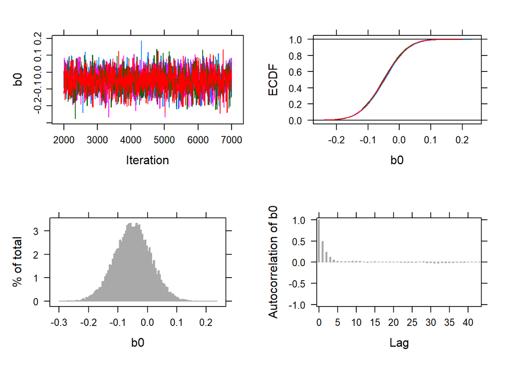

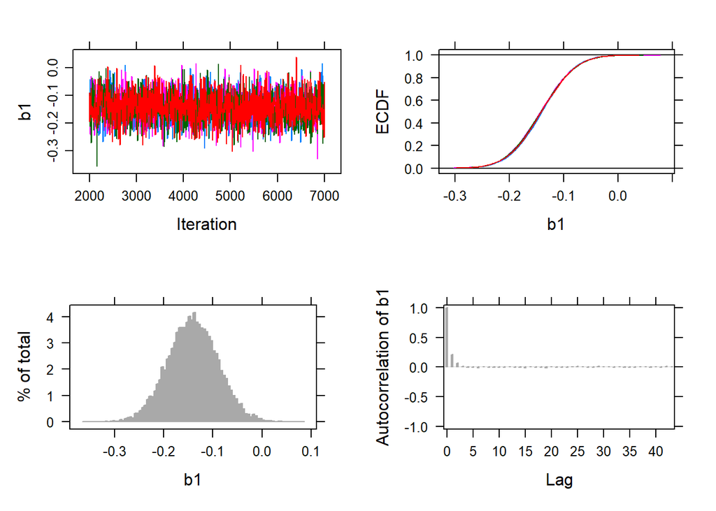

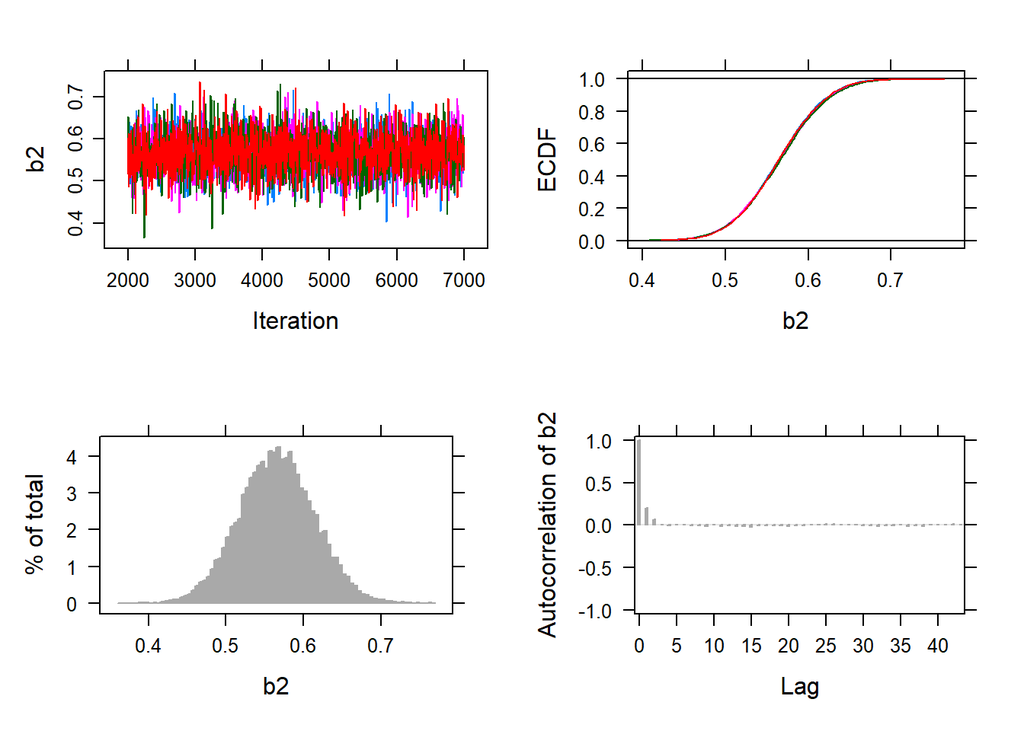

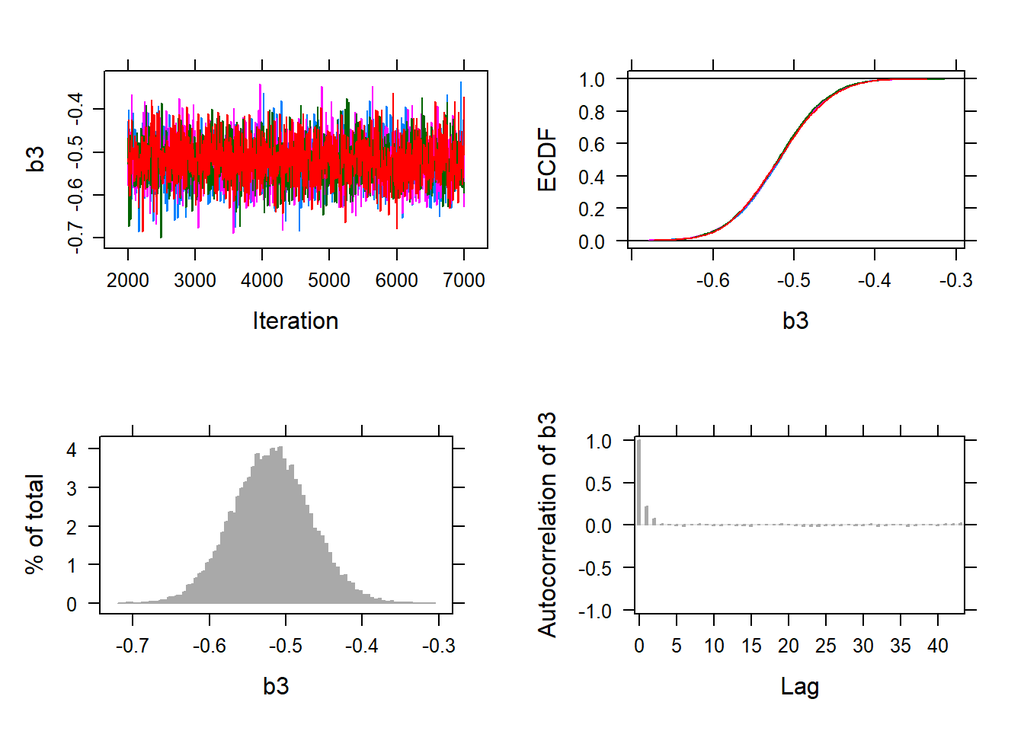

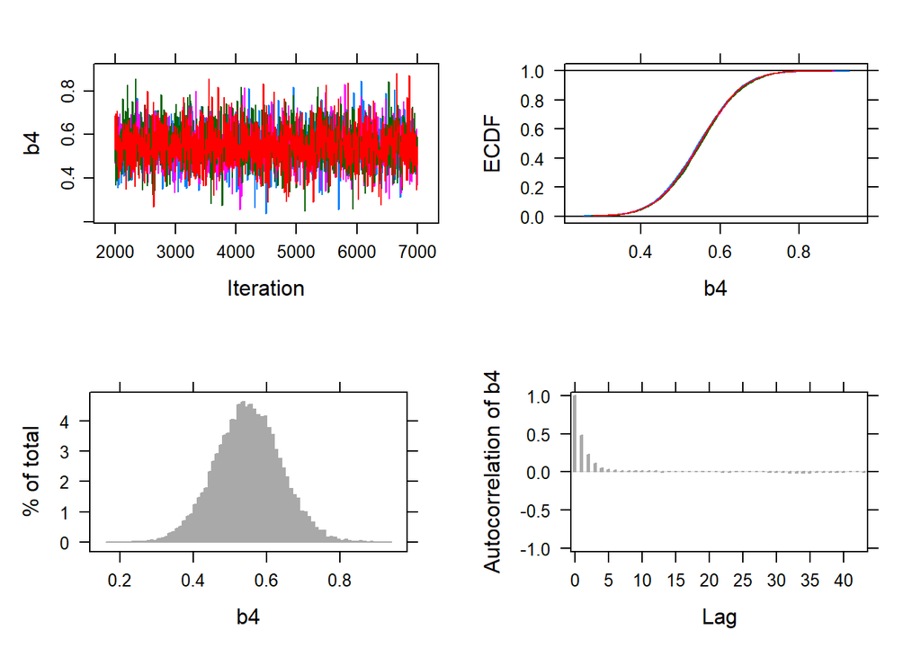

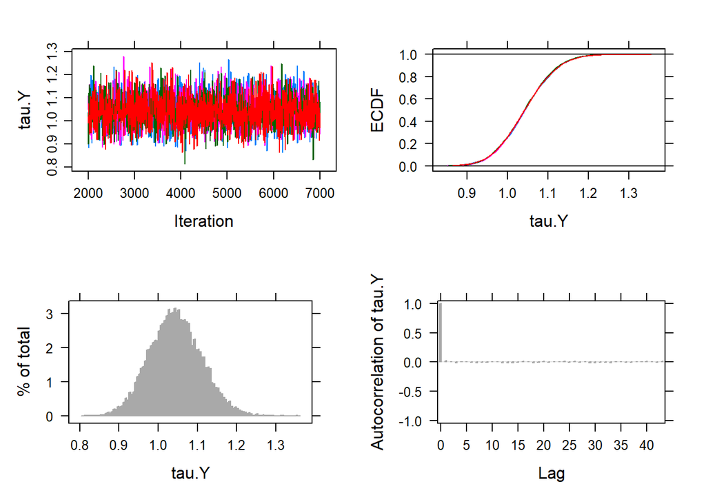

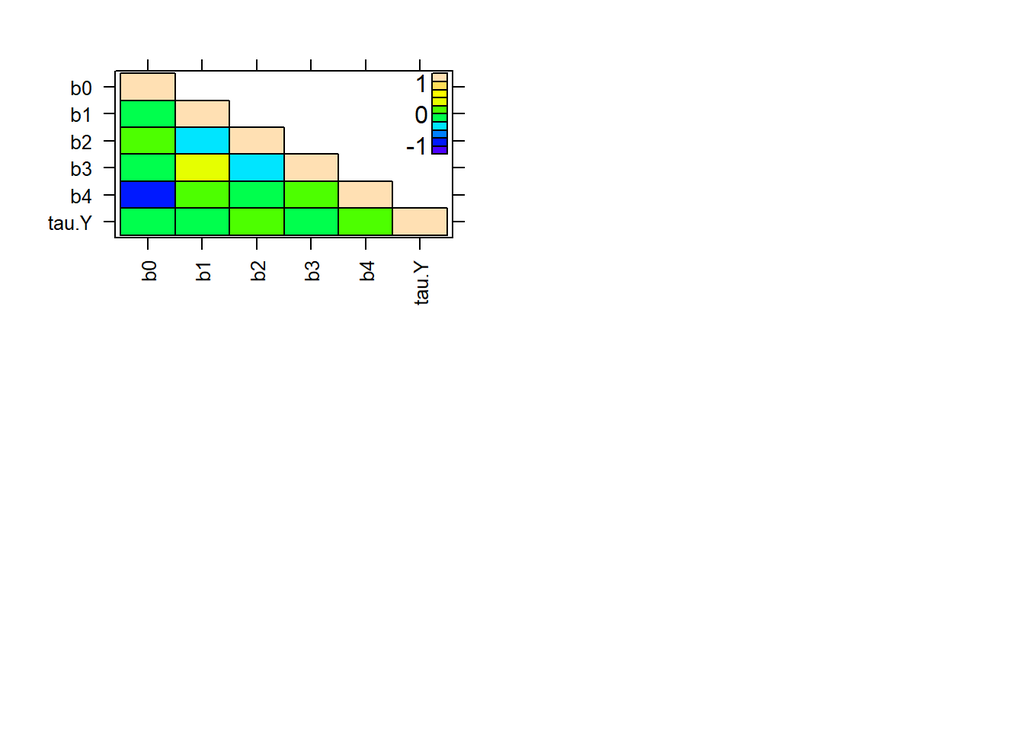

```r
plot(results.JAGS.min)
```

And, we obtain results by taking summary statistics of the MCMC posterior draws:

```r
summary(results.JAGS.min)
```

```
##          Lower95      Median     Upper95        Mean         SD Mode
## b0    -0.1727468 -0.04958301  0.06745456 -0.04988131 0.06111299   NA
## b1    -0.2378254 -0.14089535 -0.04111078 -0.14080493 0.05032882   NA
## b2     0.4724404  0.56542484  0.66138045  0.56554097 0.04835400   NA
## b3    -0.6191995 -0.51870573 -0.41943137 -0.51880827 0.05095527   NA
## b4     0.3766708  0.54863390  0.72544703  0.54868318 0.08876734   NA
## tau.Y  0.9163576  1.04296329  1.17439821  1.04443888 0.06602836   NA
##              MCerr MC%ofSD SSeff         AC.10     psrf
## b0    0.0007543238     1.2  6564  0.0242058129 1.000286
## b1    0.0004452393     0.9 12778 -0.0086078485 1.000167
## b2    0.0004122149     0.9 13760  0.0008452970 1.000293
## b3    0.0004616492     0.9 12183 -0.0089009317 1.000073
## b4    0.0010753873     1.2  6814  0.0141558046 1.000230
## tau.Y 0.0004751798     0.7 19308  0.0009163321 1.000037
```

The posterior mean and standard deviation estimates are nearly identical to the least squares point estimates and standard errors for the minimal model. Bayes doesn’t magically solve the problem of model misspecification! We still have omitted variables bias here.

Next, we do the same for the full and true models (we’ll suppress the output here) - which also give similar results to the comparable OLS models.

```r
JAGS.full =
  "model{
  #Individual likelihood
  for (i in 1:N){
   Y[i] ~ dnorm(mu.Y[i],tau.Y)
    mu.Y[i] = b0 + b1*X[i,1] + b2*X[i,2] + b3*X[i,3] + b4*TX[i] + b5*X[i,1]*TX[i] + b6*X[i,2]*TX[i] + b7*X[i,3]*TX[i]
  }
  #Priors
  b0 ~ dnorm(0,.01)
  b1 ~ dnorm(0,.01)
  b2 ~ dnorm(0,.01)
  b3 ~ dnorm(0,.01)
  b4 ~ dnorm(0,.01)
  b5 ~ dnorm(0,.01)
  b6 ~ dnorm(0,.01)
  b7 ~ dnorm(0,.01)

  tau.Y ~ dgamma(.001,.001)
}"

inits.full <-
  replicate(
    numchains,
    list(
      b0 = runif(n = 1, min = -3, max = 3),
      b1 = runif(n = 1, min = -3, max = 3),
      b2 = runif(n = 1, min = -3, max = 3),
      b3 = runif(n = 1, min = -3, max = 3),
      b4 = runif(n = 1, min = -3, max = 3),
      b5 = runif(n = 1, min = -3, max = 3),
      b6 = runif(n = 1, min = -3, max = 3),
      b7 = runif(n = 1, min = -3, max = 3),
      tau.Y = runif(n = 1, min = .1, max = 5)
    ),
    simplify = FALSE
  )

set.seed(11235)

results.JAGS.full = run.jags(
  model = JAGS.full,
  monitor = c("b0", "b1", "b2", "b3", "b4", "b5", "b6", "b7", "tau.Y"),
  data = list(
    N = N,
    Y = Y,
    X = X,
    TX = TX
  ),
  n.chains = numchains,
  inits = inits.full,
  burnin = 1000,
  sample = 5000,
  method = "rjparallel"
)
```

```
## Compiling rjags model...
## Note: the model did not require adaptation
## Starting 4 rjags simulations using a PSOCK cluster with 4 nodes on host
## 'localhost'
## Simulation complete
## Calculating summary statistics...
## Calculating the Gelman-Rubin statistic for 9 variables....
## Finished running the simulation
```

```r
JAGS.true =
  "model{
  #Individual likelihood
  for (i in 1:N){
   Y[i] ~ dnorm(mu.Y[i],tau.Y)
    mu.Y[i] = b0 + b1*X[i,1] + b2*X[i,2] + b3*X[i,3] + b4*TX[i] + b5*X[i,1]*TX[i]
  }
  #Priors
  b0 ~ dnorm(0,.01)
  b1 ~ dnorm(0,.01)
  b2 ~ dnorm(0,.01)
  b3 ~ dnorm(0,.01)
  b4 ~ dnorm(0,.01)
  b5 ~ dnorm(0,.01)

  tau.Y ~ dgamma(.001,.001)
}"

inits.true <-
  replicate(
    numchains,
    list(
      b0 = runif(n = 1, min = -3, max = 3),
      b1 = runif(n = 1, min = -3, max = 3),
      b2 = runif(n = 1, min = -3, max = 3),
      b3 = runif(n = 1, min = -3, max = 3),
      b4 = runif(n = 1, min = -3, max = 3),
      b5 = runif(n = 1, min = -3, max = 3),
      tau.Y = runif(n = 1, min = .1, max = 5)
    ),
    simplify = FALSE
  )

set.seed(11235)

results.JAGS.true = run.jags(
  model = JAGS.true,
  monitor = c("b0", "b1", "b2", "b3", "b4", "b5", "tau.Y"),
  data = list(
    N = N,
    Y = Y,
    X = X,
    TX = TX
  ),
  n.chains = numchains,
  inits = inits.true,
  burnin = 1000,
  sample = 5000,
  method = "rjparallel"
)
```

```
## Compiling rjags model...
## Note: the model did not require adaptation
## Starting 4 rjags simulations using a PSOCK cluster with 4 nodes on host
## 'localhost'
## Simulation complete
## Calculating summary statistics...
## Calculating the Gelman-Rubin statistic for 7 variables....
## Finished running the simulation
```

We can use the deviance information criterion (DIC) to compare models. DIC is a function of the mean of model deviance $D(\theta_s) = -2 \mbox{ log} (p(y|\theta_s))$, evaluated at each MCMC draw $s$, and the number of effective parameters in the model. Lower values of DIC indicate better fit (higher likelihood) for the level of model complexity (lower number of parameters).

```r
dic.min = runjags::extract(results.JAGS.min,what = "dic")
```

```
## Compiling rjags model and adapting for 1000 iterations...
## Obtaining DIC samples from 5000 iterations...
```

```r
dic.full = runjags::extract(results.JAGS.full,what = "dic")
```

```
## Compiling rjags model and adapting for 1000 iterations...
## Obtaining DIC samples from 5000 iterations...
```

```r
dic.true = runjags::extract(results.JAGS.true,what = "dic")
```

```
## Compiling rjags model and adapting for 1000 iterations...
## Obtaining DIC samples from 5000 iterations...
```

```r
diffdic(dic.full,dic.min)
```

```
## Difference: -3.530469
## Sample standard error: 5.801503
```

```r
diffdic(dic.true,dic.full)
```

```
## Difference: -1.939095
## Sample standard error: 2.730887
```

```r
diffdic(dic.true,dic.min)
```

```
## Difference: -5.469564
## Sample standard error: 5.16518
```

There’s no absolute scale for comparing DIC, but because the deviance and penalty are calculated at each sampled observation the difference in DIC between two models has a sample standard error that gives us a magnitude for comparison. In this case, the differences in DIC are not large relative to the sample standard error of the difference in DIC, suggesting not a strong preference for one model over another.

## The Bayesian Approach: Stan

Stan is currently one of the most actively-developed software platforms for Bayesian estimation, largely because of its integration with R. Like JAGS/BUGS, Stan has a programming syntax that allows for a vast array of customized models. But for the vast majority of applied modeling, pre-compiled models have been developed to use with helper packages like ‘brms’ and ‘rstanarm’. With the brms package, you can actually view the Stan code generated by a simple model. For example:

```r
brms.min = brms::brm(formula =  Y ~ X1 + X2 + X3 + TX,
  data = D)

brms::stancode(brms.min)
```

```
## // generated with brms 2.16.1
## functions {
## }
## data {
##   int<lower=1> N;  // total number of observations
##   vector[N] Y;  // response variable
##   int<lower=1> K;  // number of population-level effects
##   matrix[N, K] X;  // population-level design matrix
##   int prior_only;  // should the likelihood be ignored?
## }
## transformed data {
##   int Kc = K - 1;
##   matrix[N, Kc] Xc;  // centered version of X without an intercept
##   vector[Kc] means_X;  // column means of X before centering
##   for (i in 2:K) {
##     means_X[i - 1] = mean(X[, i]);
##     Xc[, i - 1] = X[, i] - means_X[i - 1];
##   }
## }
## parameters {
##   vector[Kc] b;  // population-level effects
##   real Intercept;  // temporary intercept for centered predictors
##   real<lower=0> sigma;  // dispersion parameter
## }
## transformed parameters {
## }
## model {
##   // likelihood including constants
##   if (!prior_only) {
##     target += normal_id_glm_lpdf(Y | Xc, Intercept, b, sigma);
##   }
##   // priors including constants
##   target += student_t_lpdf(Intercept | 3, 0.2, 2.5);
##   target += student_t_lpdf(sigma | 3, 0, 2.5)
##     - 1 * student_t_lccdf(0 | 3, 0, 2.5);
## }
## generated quantities {
##   // actual population-level intercept
##   real b_Intercept = Intercept - dot_product(means_X, b);
## }
```

Luckily, brms or rstanarm does the hard work for us. We will show how to estimate the above models using rstanarm and compare them using pareto-smoothed importance sampling / leave-one-out cross-validation methods. As you can see from the code below, using stan to estimate simple glm models is as easy with classical methods. Note that unless we specify priors to contain information, Stan will use minimally informative default priors - point estimates and posterior standard deviations should be very close to classical OLS/ML estimates and standard errors for most simple models.

```r
stanfit.min = stan_glm(
  Y ~ X1 + X2 + X3 + TX,
  data = D,
  chains = 4,
  seed = 11235
)

stanfit.full = stan_glm(
  Y ~ X1 + X2 + X3 + TX + X1 * TX + X2 * TX + X3 * TX,
  data = D,
  chains = 4,
  seed = 11235
)

stanfit.true = stan_glm(
  Y ~ X1 + X2 + X3 + TX + X1 * TX ,
  data = D,
  chains = 4,
  seed = 11235
)
```

We can summarize the posterior draws to obtain point estimates and credible intervals.

```r
summary(stanfit.min,digits = 3)
```

```
##
## Model Info:
##  function:     stan_glm
##  family:       gaussian [identity]
##  formula:      Y ~ X1 + X2 + X3 + TX
##  algorithm:    sampling
##  sample:       4000 (posterior sample size)
##  priors:       see help('prior_summary')
##  observations: 500
##  predictors:   5
##
## Estimates:
##               mean   sd     10%    50%    90%
## (Intercept) -0.049  0.061 -0.127 -0.049  0.031
## X1          -0.141  0.050 -0.206 -0.142 -0.077
## X2           0.566  0.048  0.505  0.565  0.627
## X3          -0.520  0.051 -0.585 -0.519 -0.456
## TX           0.547  0.089  0.433  0.547  0.660
## sigma        0.981  0.032  0.941  0.980  1.023
##
## Fit Diagnostics:
##            mean   sd    10%   50%   90%
## mean_PPD 0.223  0.063 0.142 0.222 0.303
##
## The mean_ppd is the sample average posterior predictive distribution of the outcome variable (for details see help('summary.stanreg')).
##
## MCMC diagnostics
##               mcse  Rhat  n_eff
## (Intercept)   0.001 1.000 6019
## X1            0.001 1.000 3532
## X2            0.001 1.001 3883
## X3            0.001 1.001 3639
## TX            0.001 1.000 6262
## sigma         0.000 1.000 5714
## mean_PPD      0.001 0.999 5052
## log-posterior 0.042 1.003 1710
##
## For each parameter, mcse is Monte Carlo standard error, n_eff is a crude measure of effective sample size, and Rhat is the potential scale reduction factor on split chains (at convergence Rhat=1).
```

We can visualize our posterior draws using ggplot2 methods defined for stanreg objects.

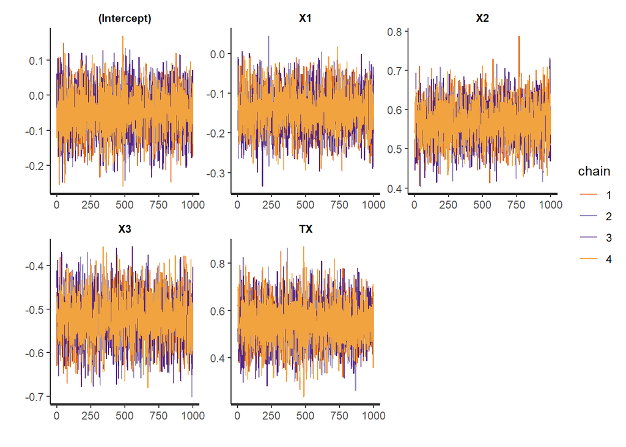

```r
stan_trace(stanfit.min)
```

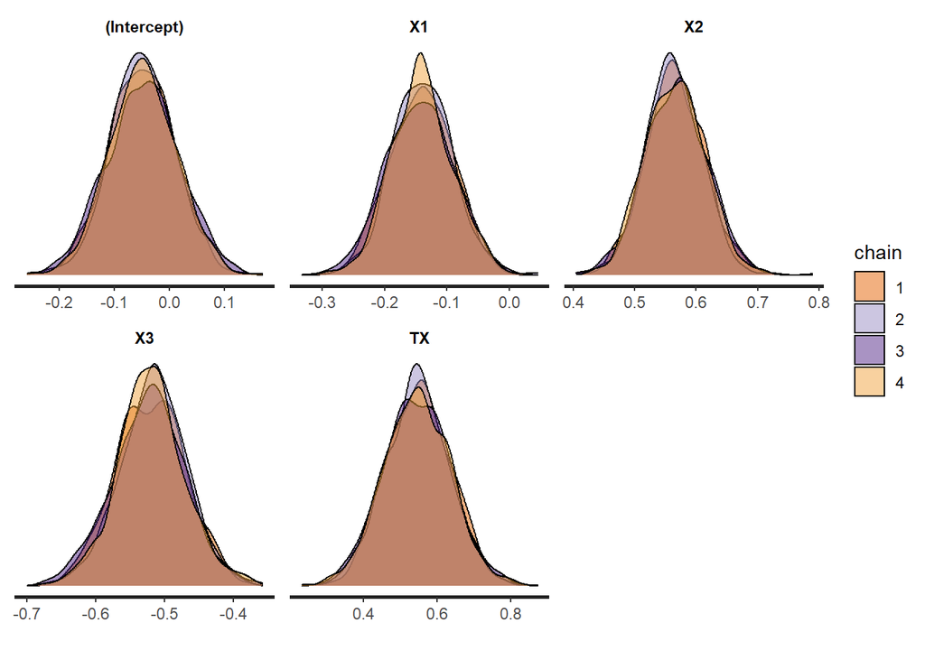

```r
stan_dens(stanfit.min,separate_chains = TRUE)
```

```
## ci_level: 0.8 (80% intervals)
```

```
## outer_level: 0.95 (95% intervals)
```

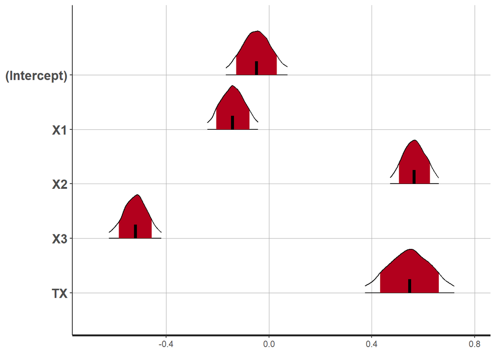

```r
stan_plot(stanfit.min, show_density = TRUE)
```

Finally, we will compare models using a method based on Bayesian decision theory. If a decision-maker derives utility from making accurate predictions, we might like to choose the model that minimizes squared prediction error. For true predictive validity, we need external/future data - which we don’t really have access to. Instead, we use the principle of cross-validation, which mimics external data by holding out a subset of available data from the modeling process and then predicting those out-of-sample observations. Leave-one-out (LOO) cross-validation does this $N$ times - leaving out each observation $i = 1...N$ and predicting it using estimates obtained from the remaining $N-1$ observations. This process generates a LOO information criterion (LOO-IC), similar to the DIC - but more robust to complex models.

```r
stanfit.min$loo = loo(stanfit.min, cores = 4)
stanfit.full$loo = loo(stanfit.full, cores = 4)
stanfit.true$loo = loo(stanfit.true, cores = 4)

model_list <-
  stanreg_list(
    stanfit.min,
    stanfit.full,
    stanfit.true,
    model_names = c("No Interactions", "Full Model", "True Model")
  )

loo_compare(model_list, detail = TRUE)
```

```
## Model formulas:
##  No Interactions:  Y ~ X1 + X2 + X3 + TX
##  Full Model:  Y ~ X1 + X2 + X3 + TX + X1 * TX + X2 * TX + X3 * TX
##  True Model:  Y ~ X1 + X2 + X3 + TX + X1 * TX
##
## Model comparison based on LOO-CV:
##                 elpd_diff se_diff
## True Model       0.0       0.0
## Full Model      -1.3       1.4
## No Interactions -2.8       2.6
```

We can take the thought experiment further and consider that because there is still uncertainty about which model is best, we might wish to take an average prediction generated from the models we have estimated. The method of “stacking” solves for an optimal set of weights that minimizes the squared prediction error between the combined (ensemble) prediction and the actual outcome, again, using LOO. We can interpret these weights as the probability that each model has the lowest prediction error of the models assessed.

```r
loo_model_weights(model_list)
```

```
## Method: stacking
## ------
##                 weight
## No Interactions 0.086
## Full Model      0.000
## True Model      0.914
```

In this example, the true model (fortunately!) has the highest probability of being correct - 91.4%, and if we were to use an ensemble prediction, only the true model and the minimal model would be included, with the true model geting over 10 times the weight as the minimal model.